# Predicción de precios de Bitcoin

Se intenta predecir los precios de Bitcoin, utilizando datos de las cotizaciones históricas entre 2015 y 2023. Se comparan dos técnicas: un modelo ARIMA de series de tiempo y un bosque aleatorio.

## 1) Carga de datos

Los datos se descargan de [Yahoo! Finance](https://finance.yahoo.com/quote/BTC-USD/). Se obtiene la cotización diaria del BTC en dólares entre el 01/01/2015 y el 31/12/2023. El archivo .csv es convertido a .xlsx e importado a Python, estableciendo la fecha como índice.

```python
#Librerías
import pandas as pd
import warnings
from statsmodels.tools.sm_exceptions import  ValueWarning
warnings.filterwarnings('ignore')
warnings.simplefilter(action='ignore', category=Warning)
warnings.simplefilter('ignore', ValueWarning)

#Carga de datos
datos = pd.read_excel('btc.xlsx')
datos.set_index('fecha', inplace=True)
```

## 2) Análisis exploratorio

Se lleva cabo un análisis descriptivo de los datos. Se grafica la serie temporal y se calculan medidas de resumen.

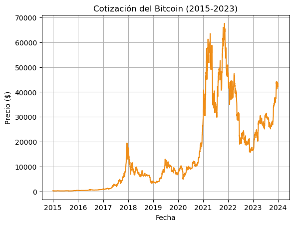

```
count     3287.000000
mean     15041.625620
std      16242.203249
min        178.102997
25%       1187.840027
50%       8659.487305
75%      25369.524414
max      67566.828125
Name: BTC, dtype: float64
```

```python
#Librerías
import numpy as np
import matplotlib.pyplot as plt

#Gráfico
plt.figure()
plt.plot(datos.index, datos["BTC"], color='#ef8e19')
plt.title("Cotización del Bitcoin (2015-2023)")
plt.xlabel('Fecha')
plt.ylabel('Precio ($)')
plt.grid()
plt.show()

#Medidas descriptivas
print(datos["BTC"].describe())
```

## 3) Modelo ARIMA

Se importan las librerías necesarias para ajustar el modelo ARIMA. A continuación, las observaciones de noviembre y diciembre de 2023 son apartadas para servir como conjunto de prueba.

```python
#Librerías
import pmdarima
from statsmodels.graphics.tsaplots import plot_acf, plot_pacf
from statsmodels.tsa.arima.model import ARIMA

#Conjuntos de entrenamiento y prueba
n_prueba = 61
train, test = datos["BTC"].dropna()[:-n_prueba], datos["BTC"].dropna()[-n_prueba:]
```

Se grafican las funciones de autocorrelación y autocorrelación parcial. Luego, se ajusta automáticamente un modelo ARIMA utilizando la función *auto_arima*.

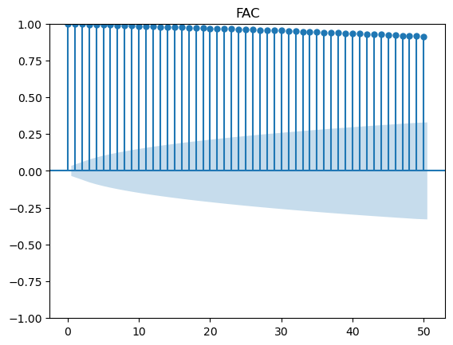

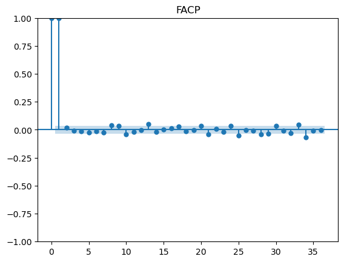

```python
#Funciones de autocorrelación
plot_acf(train, title= "FAC", lags=50)
print()
plot_pacf(train, title= "FACP")
print()
```

```python
#Modelo automático
modelo_arima = pmdarima.auto_arima(train, random_state=30062000)
print("Modelo: ARIMA", modelo_arima.order)
```

```
Modelo: ARIMA (2, 1, 2)
```

Se vuelven a realizar los gráficos, esta vez para la serie diferenciada.

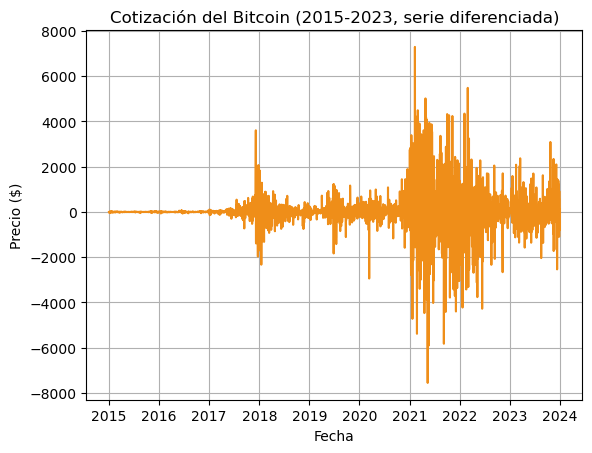

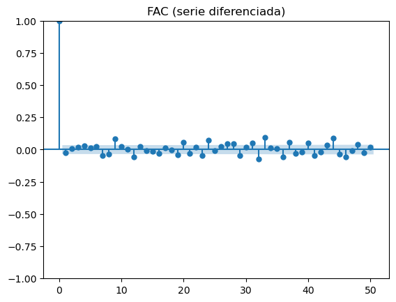

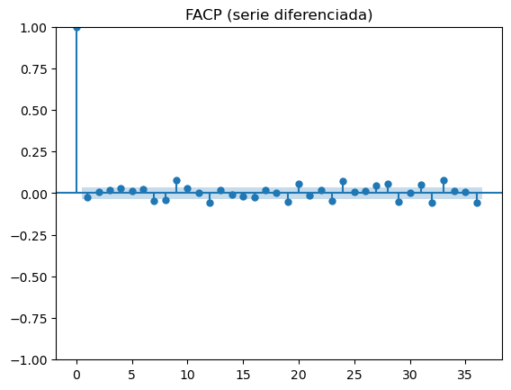

```python
# Serie diferenciada
plt.figure()
plt.plot(datos.index[1:], datos["BTC"].diff().dropna(), color='#ef8e19')
plt.title("Cotización del Bitcoin (2015-2023, serie diferenciada)")
plt.xlabel('Fecha')
plt.ylabel('Precio ($)')
plt.grid()
plt.show()

# Funciones de autocorrelación
plot_acf(train.diff().dropna(), title= "FAC (serie diferenciada)", lags=50)
print()
plot_pacf(train.diff().dropna(), title= "FACP (serie diferenciada)")
print()
```

Se realizan las predicciones para los meses del conjunto de prueba, utilizando la técnica de *Walk-Forward Validation*.

```python
#Predicciones
predicciones = list()

for t in range(len(test)):
 fecha_previa = train.index[-1]
 fecha_nueva = fecha_previa + pd.DateOffset(days=1)
 modelo_arima = ARIMA(train, order=(2,1,2))
 modelo_arima_fit = modelo_arima.fit()
 nueva_pred = modelo_arima_fit.forecast()[0]
 predicciones.append(nueva_pred)
 val_obs = test[t]
 train[fecha_nueva] = val_obs

predicciones_serie = pd.Series(predicciones, index=test.index)
```

Se grafican las predicciones junto a los verdaderos valores y se calcula también el [MAPE](https://en.wikipedia.org/wiki/Mean_absolute_percentage_error) (error de porcentaje medio absoluto).

```
MAPE:  0.016503406575316897
```

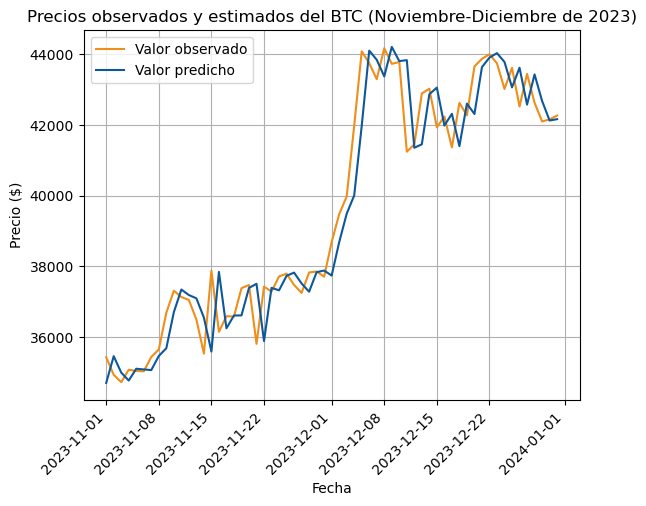

```python
#Cálculo del MAPE
mape = np.mean(np.abs((test - predicciones_serie) / predicciones_serie))
print("MAPE: ", mape)

#Gráfico
plt.figure()
plt.plot(test, label = "Valor observado", color = "#ef8e19")
plt.plot(predicciones_serie, label = "Valor predicho", color = "#0d579b")
plt.title("Precios observados y estimados del BTC (Noviembre-Diciembre de 2023)")
plt.xlabel('Fecha')
plt.ylabel('Precio ($)')
plt.xticks(rotation = 45, ha = "right")
plt.grid()
plt.legend(loc = 2)
plt.show()
```

## 4) Random Forest

Se importan las librerías necesarias para ajustar un modelo de bosques aleatorios (random forest). Se utilizará la cotización diaria como variable respuesta y la cotización del día anterior como variable expicativa. Una vez más, las observaciones de noviembre y diciembre de 2023 son apartadas para ser predichas posteriormente por el modelo.

```python
#Liibrerías
import warnings
from sklearn.ensemble import RandomForestRegressor
from sklearn.model_selection import GridSearchCV

#Calcular precios del día anterior
x = datos["BTC"].dropna().shift(1)
y = datos["BTC"].dropna()
precios = pd.concat([y,x], axis=1, keys=['y', 'x']).dropna()

#Dividir en conjunto de entrenamiento y prueba
train, test = precios[:-n_prueba], precios[-n_prueba:]
```

Se realiza el ajuste de los hiperparámetros. Para ello, se define una grilla con distintas opciones para cada hiperparámetro. Se aplica validación cruzada para encontrar la combinación óptima. El modelo es finalmente ajustado con dicha combinación de hiperparámetros.

```python
#Tuneo de hiperparámetros
grilla_parametros = {
    'n_estimators': [10, 50, 100, 250, 500, 1000],
    'min_samples_leaf': [1, 5, 20],
    'criterion': ['friedman_mse', 'squared_error', 'absolute_error']
}

busqueda_parametros = GridSearchCV(RandomForestRegressor(), param_grid=grilla_parametros)

busqueda_parametros_fit = busqueda_parametros.fit(
    train["x"].values.reshape(-1, 1),
    train["y"].values.reshape(-1, 1))

#Ajuste del modelo
modelo_rf = RandomForestRegressor(random_state = 30062000,
                                  n_estimators = busqueda_parametros_fit.best_params_["n_estimators"],
                                  min_samples_leaf = busqueda_parametros_fit.best_params_["min_samples_leaf"],
                                  criterion = busqueda_parametros_fit.best_params_["criterion"])

modelo_rf_fit = modelo_rf.fit(train["x"].values.reshape(-1, 1), train["y"].values.reshape(-1, 1))

print("Parámetros del modelo: ", modelo_rf_fit.get_params())
```

[output not shown]

Se realizan las predicciones para el conjunto de prueba, se grafican junto a los valores observados y se calcula el MAPE.

```
MAPE:  0.03278728123660911
```

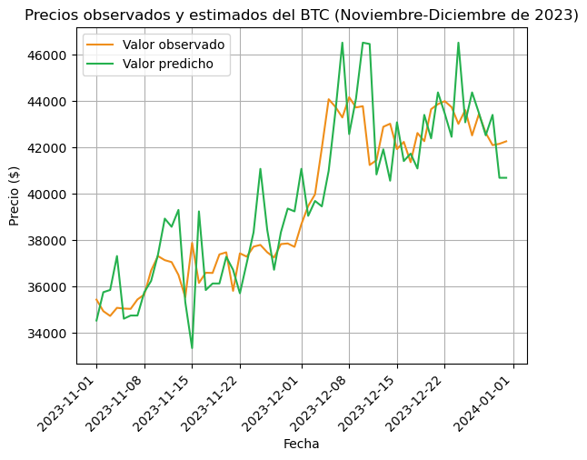

```python
#Predicciones
pred_rf = modelo_rf.predict(test["x"].values.reshape(-1, 1))
test["pred"] = pred_rf

#Cálculo del MAPE
mape = np.mean(np.abs((test["y"] - test["pred"]) / test["pred"]))
print("MAPE: ", mape)

#Gráfico
plt.figure()
plt.plot(test["y"], label = "Valor observado", color = "#ef8e19")
plt.plot(test["pred"], label = "Valor predicho", color = "#25b14e")
plt.title("Precios observados y estimados del BTC (Noviembre-Diciembre de 2023)")
plt.xlabel('Fecha')
plt.ylabel('Precio ($)')
plt.xticks(rotation = 45, ha = "right")
plt.grid()
plt.legend(loc = 2)
```

## 5) Conclusión

Ambas técnicas realizaron estimaciones satisfactorias para los precios de Bitcoin. Utilizando el MAPE como criterio de comparación, el modelo ARIMA tuvo desempeño ligeramente superior (MAPE = 0,016) a Random Forest (MAPE = 0,032). El siguiente gráfico muestra los verdaderos precios junto a las predichos por ambas técnicas.

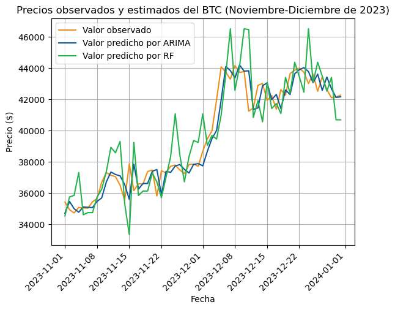

```python
plt.figure()
plt.plot(test["y"], label = "Valor observado", color = "#ef8e19")
plt.plot(predicciones_serie, label = "Valor predicho por ARIMA", color = "#0d579b")
plt.plot(test["pred"], label = "Valor predicho por RF", color = "#25b14e")
plt.title("Precios observados y estimados del BTC (Noviembre-Diciembre de 2023)")
plt.xlabel('Fecha')
plt.ylabel('Precio ($)')
plt.xticks(rotation = 45, ha = "right")
plt.grid()
plt.legend(loc = 2)
```